# Sari’s Scots Pine light experiment PCA and Heatmap

Nicolas Delhomme

2017-11-26

# 1 Setup

Set the working dir

```r
setwd("/mnt/picea/projects/spruce/rgarcia/light")
```

Load libraries

```r
suppressPackageStartupMessages(library(DESeq2))
suppressPackageStartupMessages(library(gplots))
suppressPackageStartupMessages(library(hyperSpec))
suppressPackageStartupMessages(library(matrixStats))
suppressPackageStartupMessages(library(RColorBrewer))
```

Helper

```r
source("~/Git/UPSCb/src/R/featureSelection.R")
source("~/Git/UPSCb/src/R/expressionSpecificityUtility.R")
```

Palettes

```r
pal <- brewer.pal(3,"Dark2")
hpal <- colorRampPalette(c("blue","white","red"))(100)
```

Create the list of genes of interest

```r
gene.list <- mclapply(dir("~/Git/UPSCb/projects/spruce-pine-light/doc",
             pattern="-1percent.csv$",
             full.names = TRUE),
         function(f){
           co <- read.csv(f,as.is = TRUE)[,c("ID_pine","ID_spruce")]
           list(pine=unique(co$ID_pine[co$ID_pine != ""]),
                spruce=unique(co$ID_spruce[co$ID_spruce != ""]))
         },mc.cores=4L)

p.genes <- unique(unlist(sapply(gene.list,"[","pine"),use.names = FALSE))
p.genes <- sub("\\.0$","",p.genes)
s.genes <- unique(unlist(sapply(gene.list,"[","spruce"),use.names = FALSE))
```

Read the data

```r
spruce.mat <- read.csv("analysis/HTSeq/spruce_raw-unnormalised_technical-replicates-merged_data.csv",
                       row.names = 1)

pine.mat <- read.csv("analysis/HTSeq/pine_raw-unnormalised_technical-replicates-merged_data.csv",
                       row.names = 1)
rownames(pine.mat) <- sub("\\.0$","",rownames(pine.mat))
```

Rename the samples

```r
spruceIDs <- read.delim("~/Git/UPSCb/projects/spruce-pine-light/doc/spruce-ID-mapping.txt",
                        header = FALSE, as.is = TRUE)
pineIDs <- read.delim("~/Git/UPSCb/projects/spruce-pine-light/doc/pine-ID-mapping.txt",
                      header = FALSE, as.is = TRUE)

colnames(spruce.mat) <- spruceIDs[match(colnames(spruce.mat),spruceIDs[,1]),2]
colnames(pine.mat) <- pineIDs[match(colnames(pine.mat),pineIDs[,1]),2]
```

Reorder the samples

```r
spruce.mat <- spruce.mat[,order(colnames(spruce.mat))]
pine.mat <- pine.mat[,order(colnames(pine.mat))]
```

Select only the samples from 67N

```r
spruce.mat <- spruce.mat[,grep("67N",colnames(spruce.mat))]
pine.mat <- pine.mat[,grep("67N",colnames(pine.mat))]
```

# 2 Process

## 2.1 Variance Stabilisation - blind

### 2.1.1 Spruce

```r
spruce.dds <- DESeqDataSetFromMatrix(
  countData = spruce.mat,
  colData = data.frame(condition=colnames(spruce.mat)),
  design = ~ condition)

vsd <- varianceStabilizingTransformation(spruce.dds, blind=TRUE)
spruce.vst <- assay(vsd)
spruce.vst <- spruce.vst - min(spruce.vst)

write.csv(spruce.vst,"analysis/HTSeq/spruce_library-size-normalized_variance-stabilized_technical-replicates-merged_67N_data.csv")
```

### 2.1.2 Pine

```r
pine.dds <- DESeqDataSetFromMatrix(
  countData = pine.mat,
  colData = data.frame(condition=colnames(pine.mat)),
  design = ~ condition)

vsd <- varianceStabilizingTransformation(pine.dds, blind=TRUE)
pine.vst <- assay(vsd)
pine.vst <- pine.vst - min(pine.vst)

write.csv(pine.vst,"analysis/HTSeq/pine_library-size-normalized_variance-stabilized_technical-replicates-merged_67N_data.csv")
```

# 3 Figures

## 3.1 PCA

### 3.1.1 Spruce

#### 3.1.1.1 Including Dark

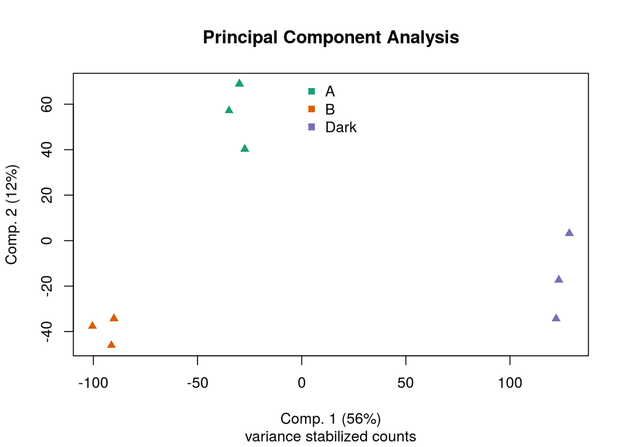

```r
dat <- spruce.vst
pc <- prcomp(t(dat))
percent <- round(summary(pc)$importance[2,]*100)
plot(pc$x[,1],
     pc$x[,2],
     xlab=paste("Comp. 1 (",percent[1],"%)",sep=""),
     ylab=paste("Comp. 2 (",percent[2],"%)",sep=""),
     col=pal[as.integer(factor(substr(colnames(dat),1,1)))],
     pch=17,
     main="Principal Component Analysis",sub="variance stabilized counts")

legend("top",legend = c("A","B","Dark"),
       pch=15,
       col=pal[1:3],
       bty="n")
```

#### 3.1.1.2 Excluding Dark

Remove the D samples (Dark)

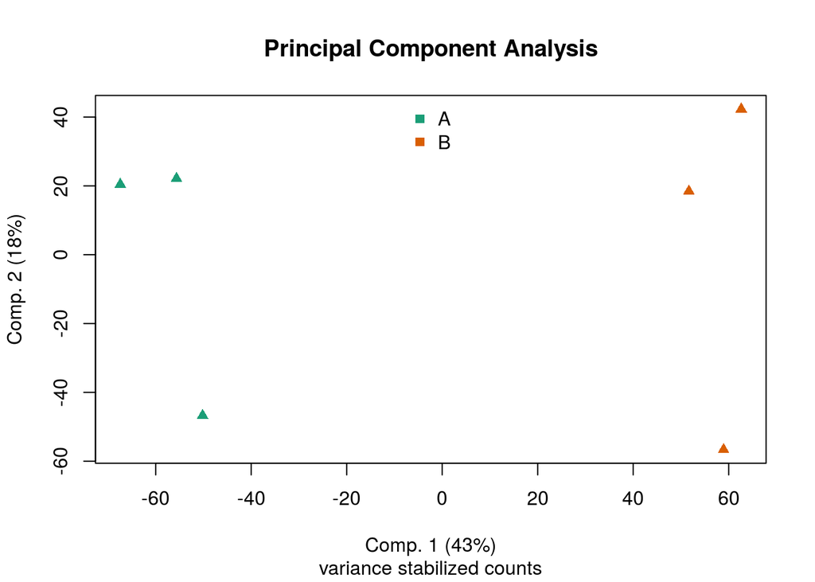

```r
dat <- spruce.vst[,substr(colnames(spruce.vst),1,1) != "D"]
pc <- prcomp(t(dat))
percent <- round(summary(pc)$importance[2,]*100)
plot(pc$x[,1],
     pc$x[,2],
     xlab=paste("Comp. 1 (",percent[1],"%)",sep=""),
     ylab=paste("Comp. 2 (",percent[2],"%)",sep=""),
     col=pal[as.integer(factor(substr(colnames(dat),1,1)))],
     pch=17,
     main="Principal Component Analysis",sub="variance stabilized counts")

legend("top",legend = c("A","B"),
       pch=15,
       col=pal[1:2],
       bty="n")
```

#### 3.1.1.3 Significant genes only

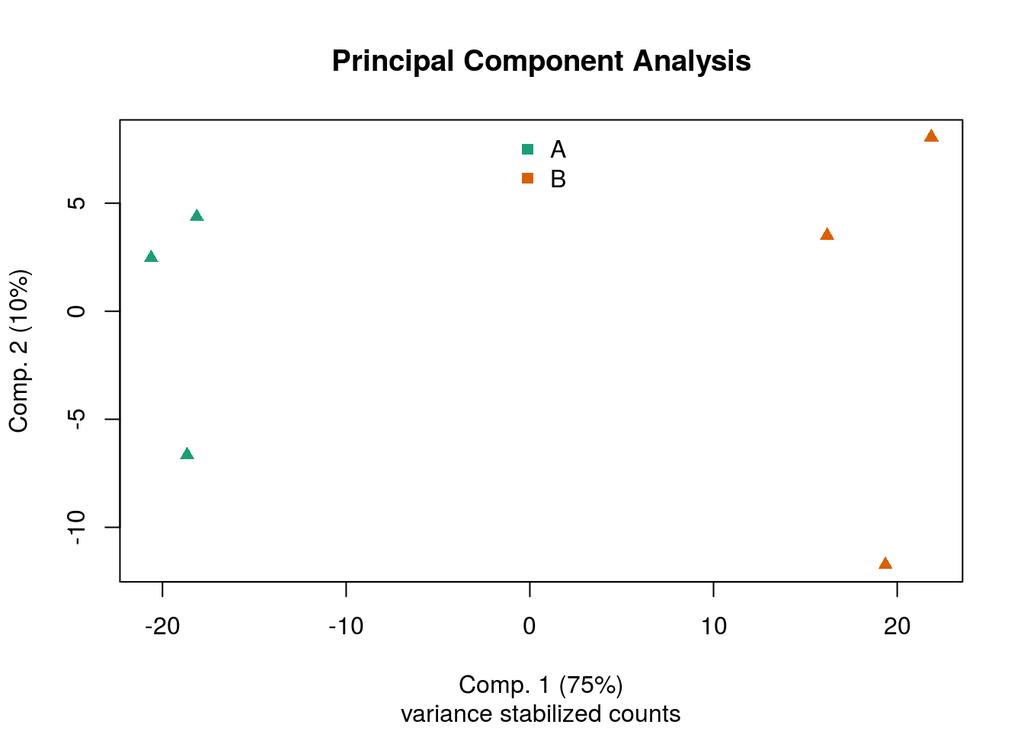

```r
dat <- spruce.vst[s.genes,
                  substr(colnames(spruce.vst),1,1) != "D"]
pc <- prcomp(t(dat))
percent <- round(summary(pc)$importance[2,]*100)
plot(pc$x[,1],
     pc$x[,2],
     xlab=paste("Comp. 1 (",percent[1],"%)",sep=""),
     ylab=paste("Comp. 2 (",percent[2],"%)",sep=""),
     col=pal[as.integer(factor(substr(colnames(dat),1,1)))],
     pch=17,
     main="Principal Component Analysis",sub="variance stabilized counts")

legend("top",legend = c("A","B"),
       pch=15,
       col=pal[1:2],
       bty="n")
```

### 3.1.2 Pine

#### 3.1.2.1 Including Dark

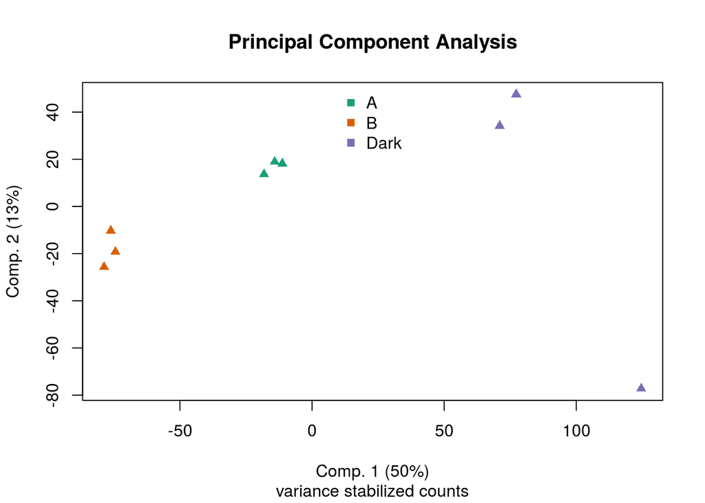

```r
dat <- pine.vst
pc <- prcomp(t(dat))
percent <- round(summary(pc)$importance[2,]*100)
plot(pc$x[,1],
     pc$x[,2],
     xlab=paste("Comp. 1 (",percent[1],"%)",sep=""),
     ylab=paste("Comp. 2 (",percent[2],"%)",sep=""),
     col=pal[as.integer(factor(substr(colnames(dat),1,1)))],
     pch=17,
     main="Principal Component Analysis",sub="variance stabilized counts")

legend("top",legend = c("A","B","Dark"),
       pch=15,
       col=pal[1:3],
       bty="n")
```

#### 3.1.2.2 Excluding Dark

Remove the D samples (Dark)

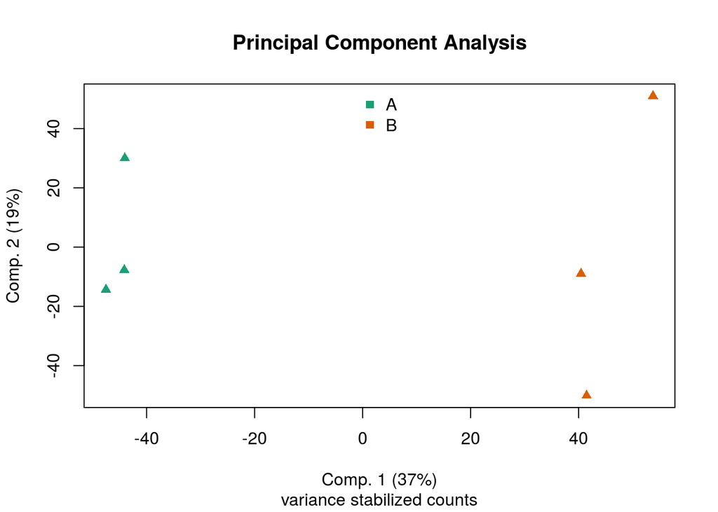

```r
dat <- pine.vst[,substr(colnames(pine.vst),1,1) != "D"]
pc <- prcomp(t(dat))
percent <- round(summary(pc)$importance[2,]*100)
plot(pc$x[,1],
     pc$x[,2],
     xlab=paste("Comp. 1 (",percent[1],"%)",sep=""),
     ylab=paste("Comp. 2 (",percent[2],"%)",sep=""),
     col=pal[as.integer(factor(substr(colnames(dat),1,1)))],
     pch=17,
     main="Principal Component Analysis",sub="variance stabilized counts")

legend("top",legend = c("A","B"),
       pch=15,
       col=pal[1:2],
       bty="n")
```

#### 3.1.2.3 Significant genes only

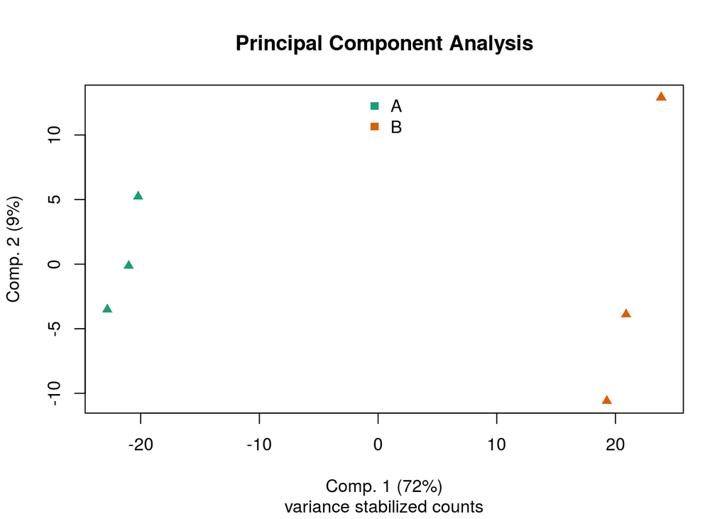

```r
dat <- pine.vst[p.genes,
                  substr(colnames(pine.vst),1,1) != "D"]
pc <- prcomp(t(dat))
percent <- round(summary(pc)$importance[2,]*100)
plot(pc$x[,1],
     pc$x[,2],
     xlab=paste("Comp. 1 (",percent[1],"%)",sep=""),
     ylab=paste("Comp. 2 (",percent[2],"%)",sep=""),
     col=pal[as.integer(factor(substr(colnames(dat),1,1)))],
     pch=17,
     main="Principal Component Analysis",sub="variance stabilized counts")

legend("top",legend = c("A","B"),
       pch=15,
       col=pal[1:2],
       bty="n")
```

## 3.2 Heatmap

### 3.2.1 Feature selection - Spruce

We select features to reduce the biological noise for visualisation

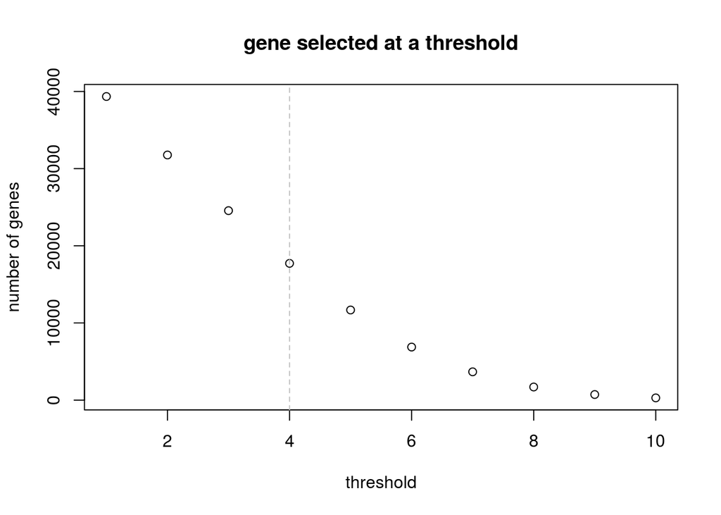

```r
s.sels <- sapply(1:10, function(i){
  featureSelect(spruce.vst,
                factor(sub("\\.\\d+$","",colnames(spruce.vst))),
                i)
})

plot(colSums(s.sels),main="gene selected at a threshold",xlab="threshold",
     ylab="number of genes")
abline(v=4,lty=2,col="grey")
```

Select the genes that have vst >= 4 in at least 2 rep out of 3

```r
s.sel <- s.sels[,4]
```

### 3.2.2 Feature selection - Pine

We select features to reduce the biological noise for visualisation

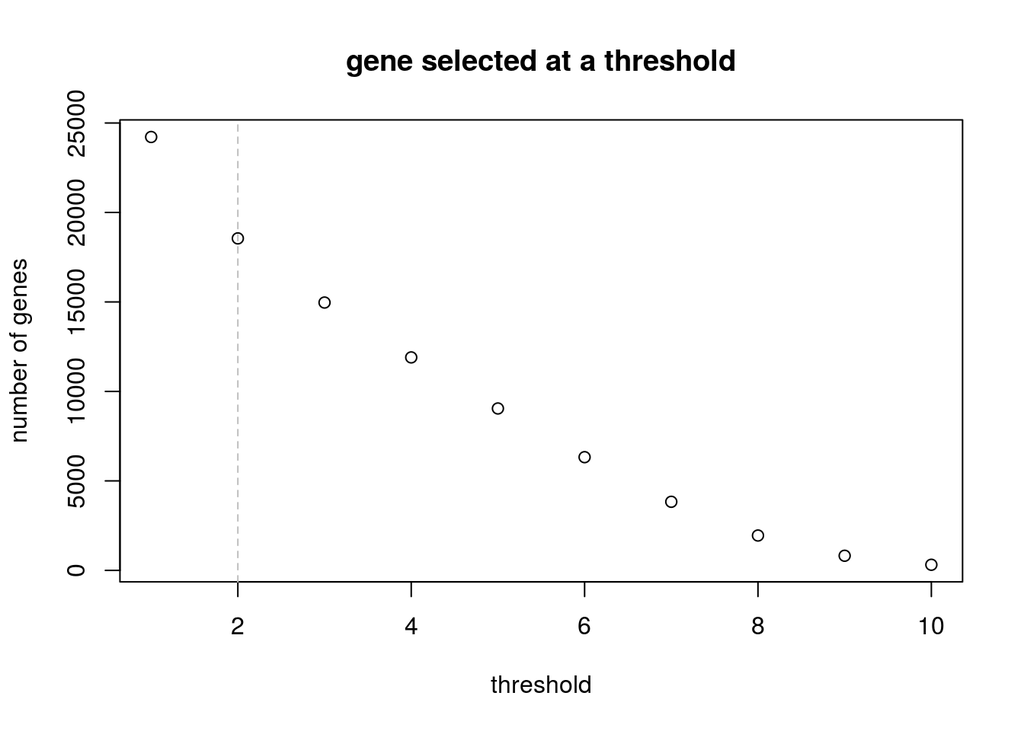

```r
p.sels <- sapply(1:10, function(i){
  featureSelect(pine.vst,
                factor(sub("\\.\\d+$","",colnames(pine.vst))),
                i)
})

plot(colSums(p.sels),main="gene selected at a threshold",xlab="threshold",
     ylab="number of genes")
abline(v=2,lty=2,col="grey")
```

```r
p.sel <- p.sels[,2]
```

### 3.2.3 Spruce

#### 3.2.3.1 Including Dark

Standard score, pearson distance, Ward clustering

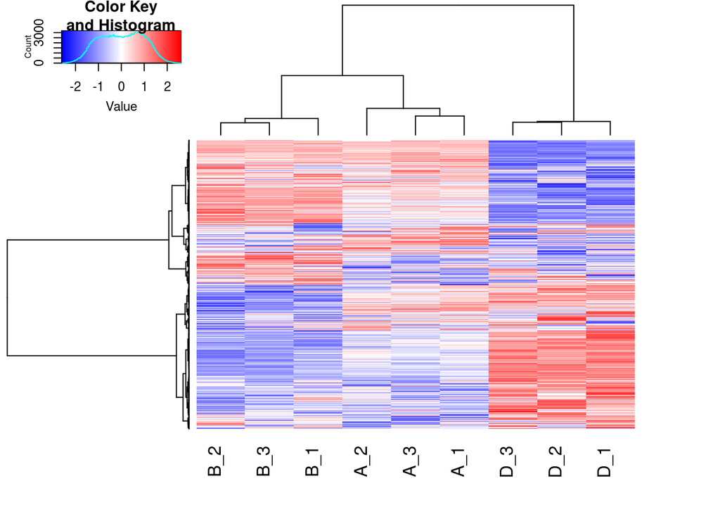

```r
s.dat <- t(scale(t(spruce.vst[s.sel,])))
heatmap.2(s.dat,labRow=NA,
          distfun = pearson.dist,
          hclustfun = function(X){hclust(X,method="ward.D")},
          trace="none",
          las=2,col=hpal,
          labCol = sub("\\.S\\.67N\\.","_",colnames(s.dat)))
```

expression values

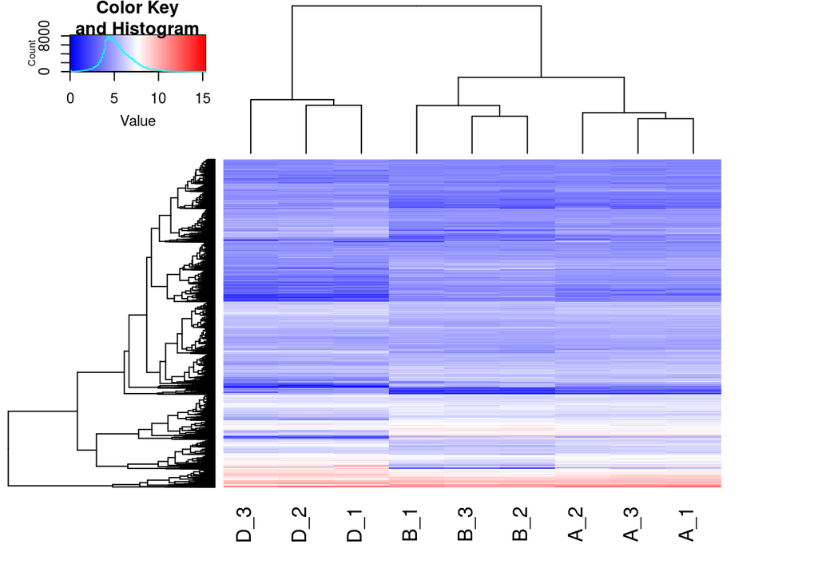

```r
dat <- spruce.vst[s.sel,]
heatmap.2(as.matrix(dat),
          labRow=NA,trace="none",
          las=2,col=hpal,
          labCol = sub("\\.S\\.67N\\.","_",colnames(dat)))
```

saturated expression

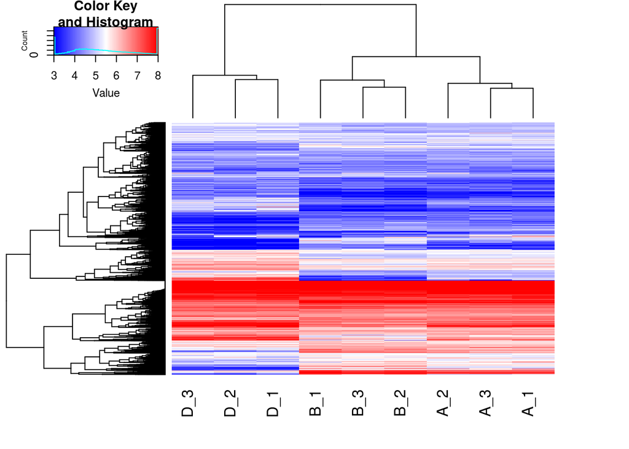

```r
dat.sat <- dat
dat.sat[dat < 3 ] <- 3
dat.sat[dat > 8 ] <- 8
heatmap.2(as.matrix(dat.sat),
          labRow=NA,trace="none",
          las=2,col=hpal,
          labCol = sub("\\.S\\.67N\\.","_",colnames(dat)))
```

#### 3.2.3.2 Excluding Dark

Standard score, pearson distance, Ward clustering

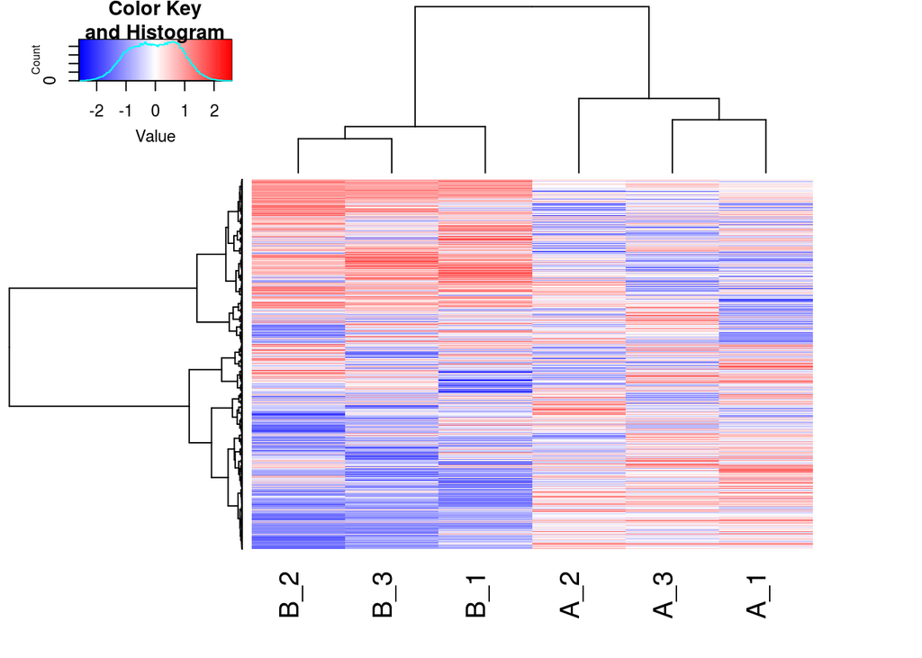

```r
s.dat <- s.dat[,substr(colnames(s.dat),1,1) != "D"]
heatmap.2(s.dat,labRow=NA,
          distfun = pearson.dist,
          hclustfun = function(X){hclust(X,method="ward.D")},
          trace="none",
          las=2,col=hpal,
          labCol = sub("\\.S\\.67N\\.","_",colnames(s.dat)))
```

expression values

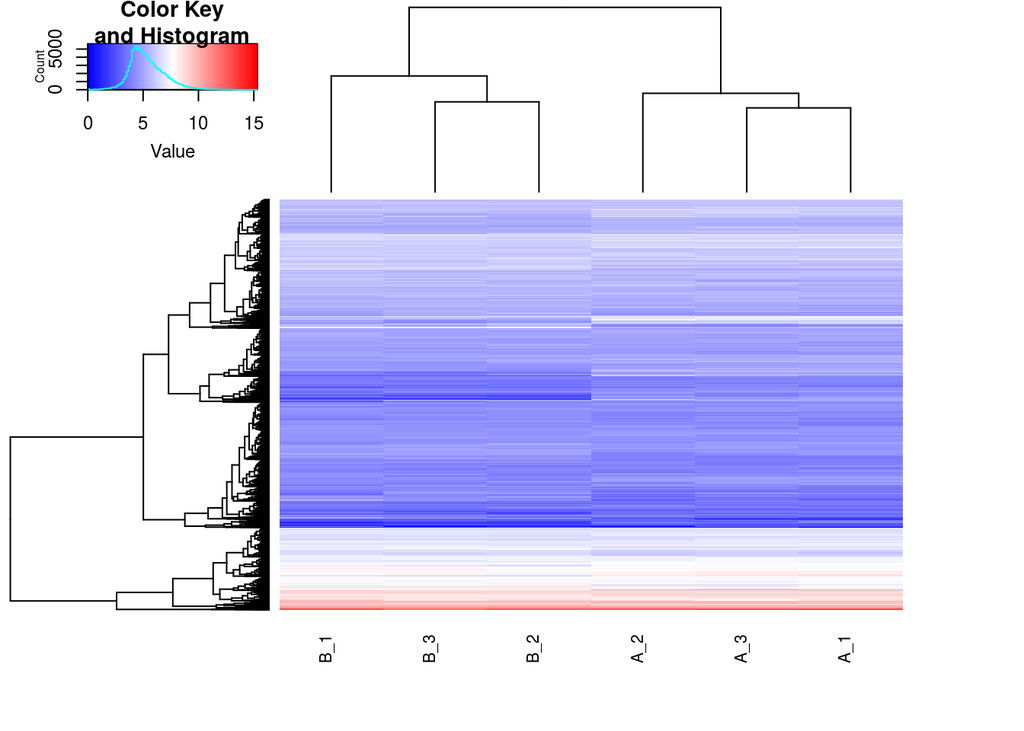

```r
dat <- dat[,substr(colnames(dat),1,1) != "D"]
heatmap.2(as.matrix(dat),
          labRow=NA,trace="none",
          las=2,col=hpal,cexCol = 0.8,
          labCol = sub("\\.S\\.67N\\.","_",colnames(dat)))
```

saturated expression

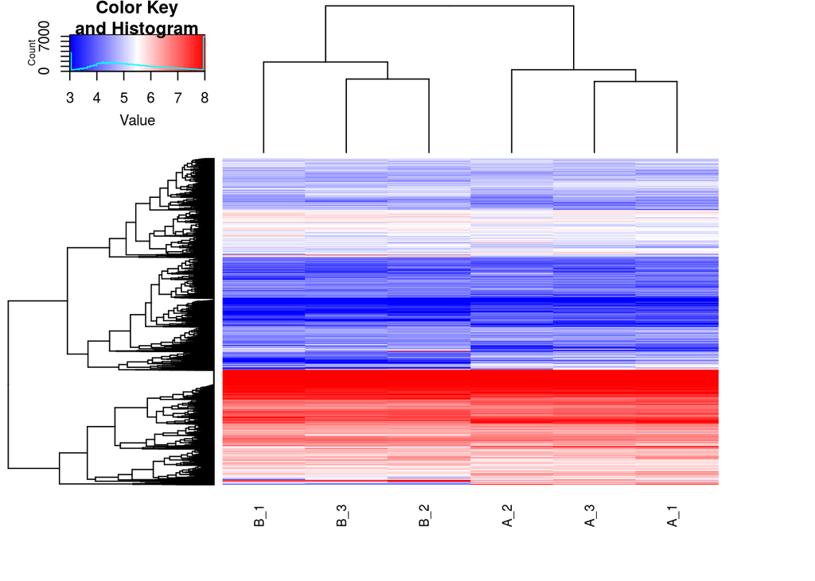

```r
dat.sat <- dat
dat.sat[dat.sat < 3 ] <- 3
dat.sat[dat.sat > 8 ] <- 8
heatmap.2(as.matrix(dat.sat),
          labRow=NA,trace="none",
          las=2,col=hpal,cexCol = 0.8,
          labCol = sub("\\.S\\.67N\\.","_",colnames(dat)))
```

saturated expression, no sample clustering

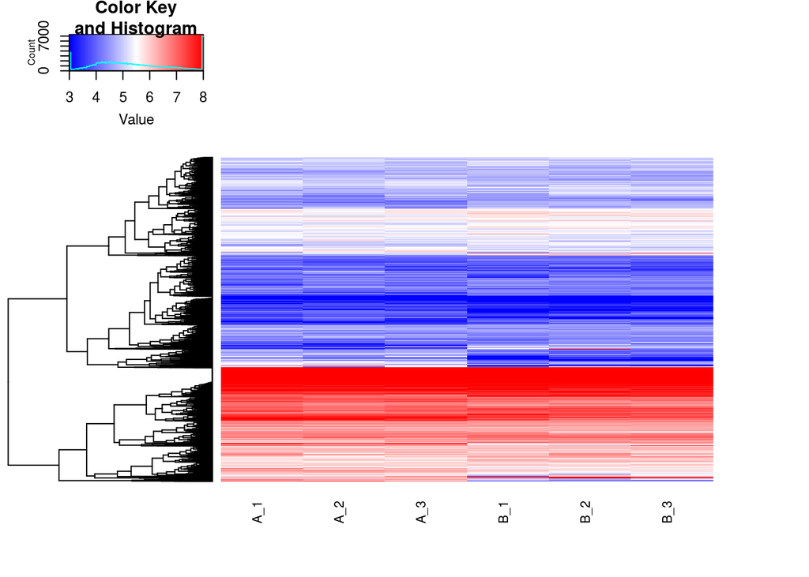

```r
heatmap.2(as.matrix(dat.sat),
          labRow=NA,trace="none",
          las=2,col=hpal,Colv = NULL,
          dendrogram="row",cexCol = 0.8,
          labCol = sub("\\.S\\.67N\\.","_",colnames(dat)))
```

#### 3.2.3.3 Gene of interest

```r
s.dat <- t(scale(t(spruce.vst[s.genes,
                              substr(colnames(s.dat),1,1) != "D"])))

message(sprintf("There are %s genes of interest that are not expressed",
                sum(is.na(rowSums(s.dat)))))
```

```
## There are 3 genes of interest that are not expressed
```

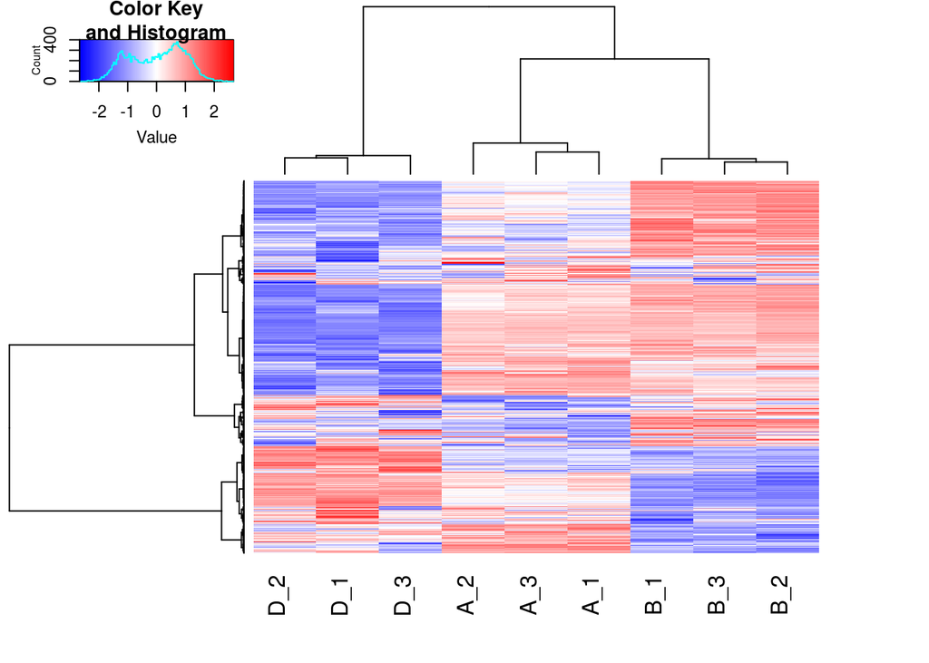

```r
heatmap.2(s.dat[!is.na(rowSums(s.dat)),],labRow=NA,
          distfun = pearson.dist,
          hclustfun = function(X){hclust(X,method="ward.D")},
          trace="none",
          las=2,col=hpal,
          labCol = sub("\\.S\\.67N\\.","_",colnames(s.dat)))
```

saturated expression

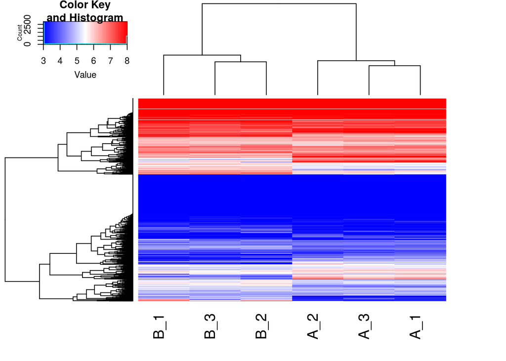

```r
dat.sat <- spruce.vst[s.genes,
                      substr(colnames(spruce.vst),1,1) != "D"]
dat.sat[dat.sat < 3 ] <- 3
dat.sat[dat.sat > 8 ] <- 8
heatmap.2(as.matrix(dat.sat),
          labRow=NA,trace="none",
          las=2,col=hpal,
          labCol = sub("\\.S\\.67N\\.","_",colnames(s.dat)))
```

### 3.2.4 Pine

#### 3.2.4.1 Including Dark

Standard score, pearson distance, Ward clustering

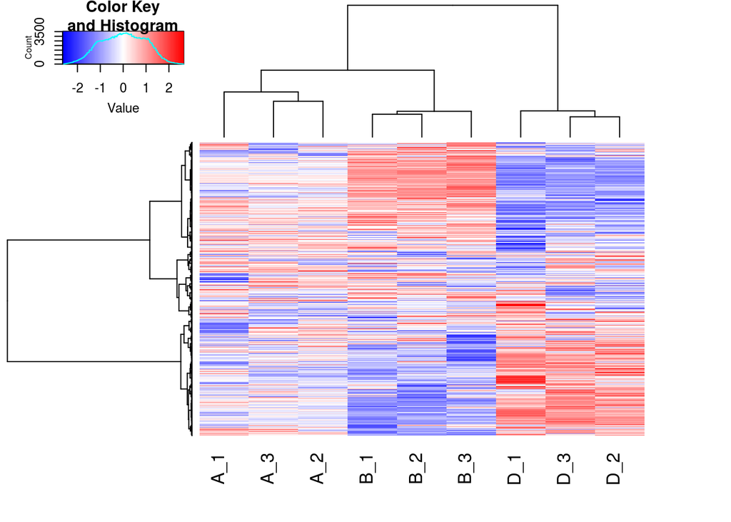

```r
s.dat <- t(scale(t(pine.vst[p.sel,])))
heatmap.2(s.dat,labRow=NA,
          distfun = pearson.dist,
          hclustfun = function(X){hclust(X,method="ward.D")},
          trace="none",
          las=2,col=hpal,
          labCol = sub("\\.P\\.67N\\.","_",colnames(s.dat)))
```

expression values

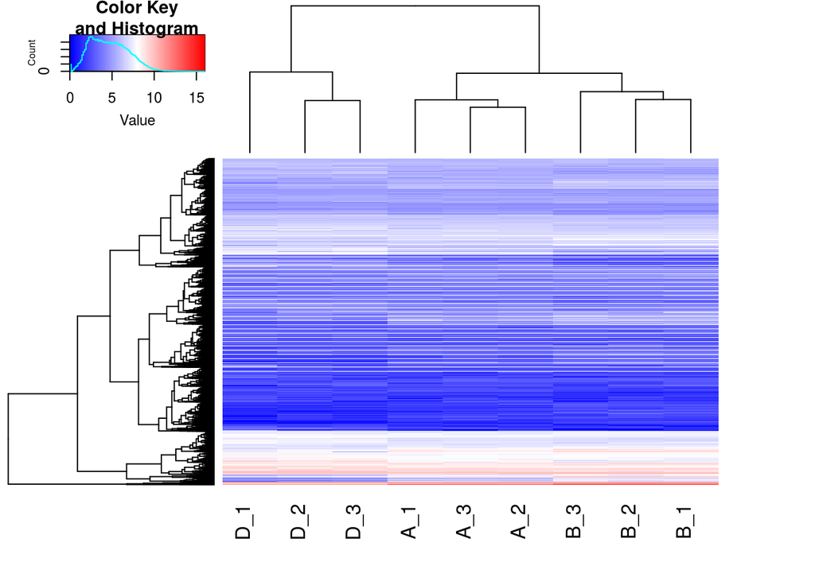

```r
dat <- pine.vst[p.sel,]
heatmap.2(as.matrix(dat),
          labRow=NA,trace="none",
          las=2,col=hpal,
          labCol = sub("\\.P\\.67N\\.","_",colnames(dat)))
```

saturated expression

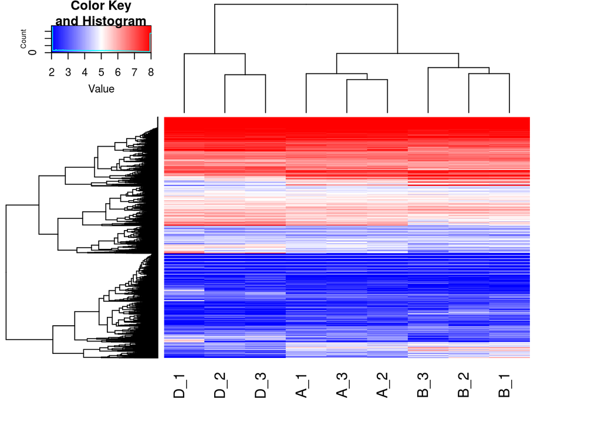

```r
dat.sat <- dat
dat.sat[dat < 2 ] <- 2
dat.sat[dat > 8 ] <- 8
heatmap.2(as.matrix(dat.sat),
          labRow=NA,trace="none",
          las=2,col=hpal,
          labCol = sub("\\.P\\.67N\\.","_",colnames(dat)))
```

#### 3.2.4.2 Excluding Dark

remove non expressed genes

```r
dat <- dat[,substr(colnames(dat),1,1) != "D"]
dat <-dat[rowSums(dat)!=0,]
```

Standard score, pearson distance, Ward clustering

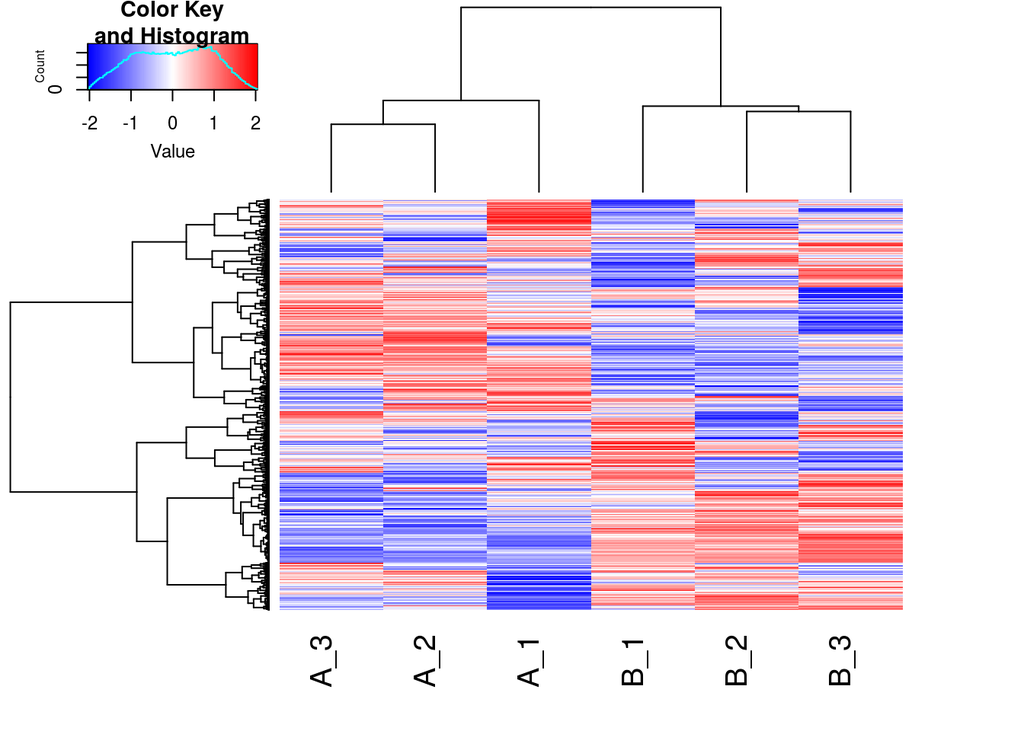

```r
s.dat <- t(scale(t(dat)))
heatmap.2(s.dat,labRow=NA,
          distfun = pearson.dist,
          hclustfun = function(X){hclust(X,method="ward.D2")},
          trace="none",
          las=2,col=hpal,
          labCol = sub("\\.P\\.67N\\.","_",colnames(s.dat)))
```

expression values

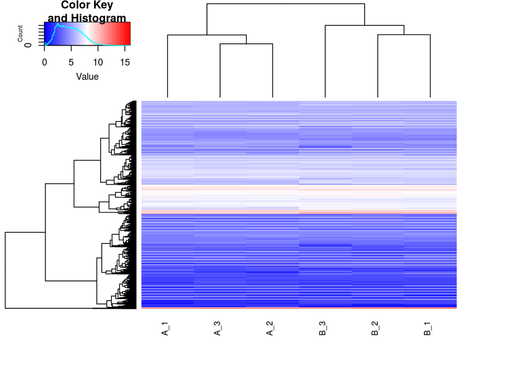

```r
heatmap.2(as.matrix(dat),
labRow=NA,trace="none",
las=2,col=hpal,cexCol = 0.8,
labCol = sub("\\.P\\.67N\\.","_",colnames(dat)))
```

saturated expression

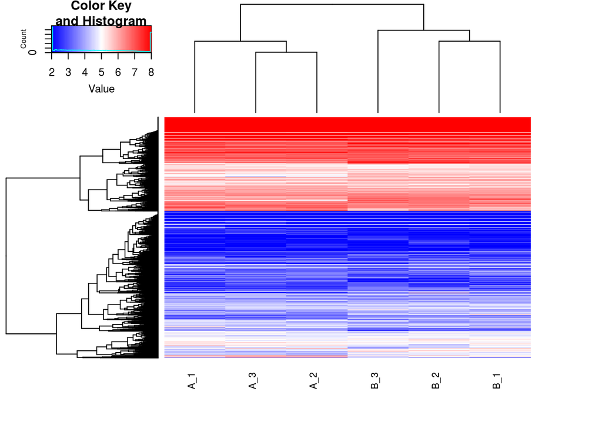

```r
dat.sat <- dat
dat.sat[dat < 2 ] <- 2
dat.sat[dat > 8 ] <- 8
heatmap.2(as.matrix(dat.sat),
          labRow=NA,trace="none",
          las=2,col=hpal,cexCol = 0.8,
          labCol = sub("\\.P\\.67N\\.","_",colnames(dat)))
```

saturated expression, no sample clustering

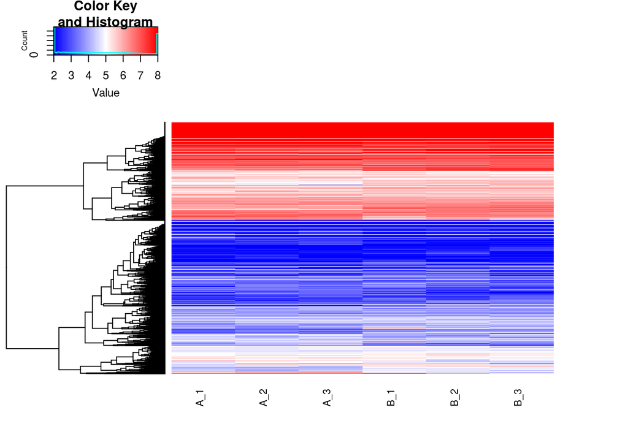

```r
heatmap.2(as.matrix(dat.sat),
          labRow=NA,trace="none",
          las=2,col=hpal,Colv = NULL,
          dendrogram="row",cexCol = 0.8,
          labCol = sub("\\.P\\.67N\\.","_",colnames(dat)))
```

#### 3.2.4.3 Gene of interest

```r
s.dat <- t(scale(t(pine.vst[p.genes,
                              substr(colnames(s.dat),1,1) != "D"])))

message(sprintf("There are %s genes of interest that are not expressed",
                sum(is.na(rowSums(s.dat)))))
```

```
## There are 0 genes of interest that are not expressed
```

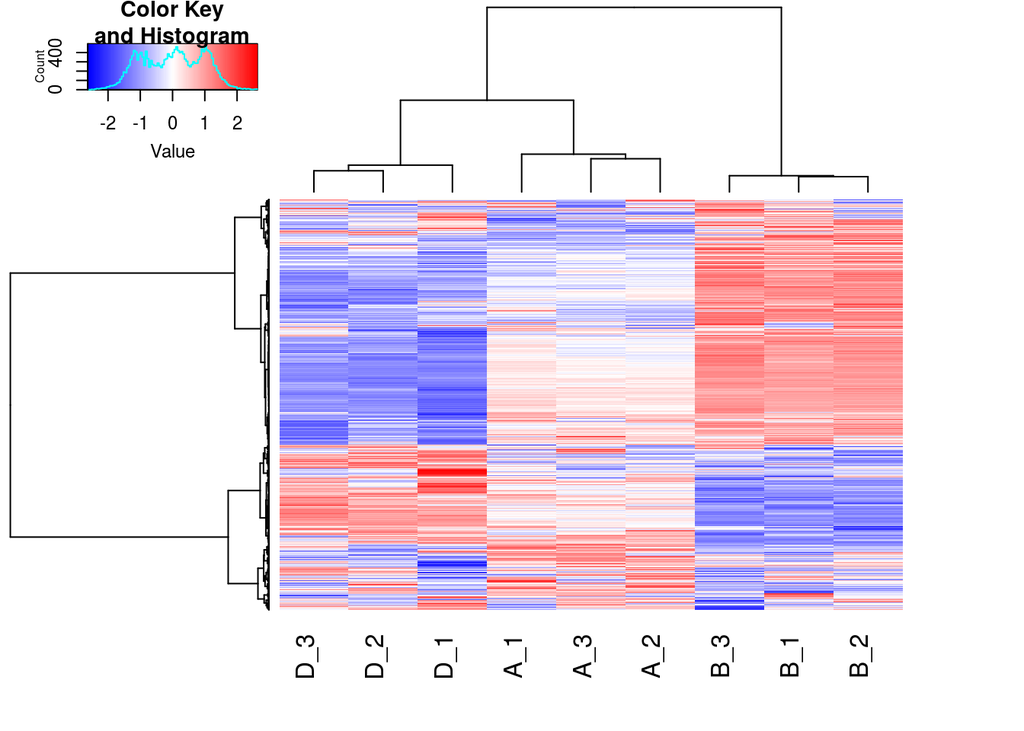

```r
heatmap.2(s.dat[!is.na(rowSums(s.dat)),],labRow=NA,
          distfun = pearson.dist,
          hclustfun = function(X){hclust(X,method="ward.D")},
          trace="none",
          las=2,col=hpal,
          labCol = sub("\\.P\\.67N\\.","_",colnames(s.dat)))
```

## 3.3 Variance Stabilisation - model aware

### 3.3.1 Spruce

```r
spruce.dds <- DESeqDataSetFromMatrix(
  countData = spruce.mat,
  colData = data.frame(light=substr(colnames(spruce.mat),1,1)),
  design = ~ light)

vsd <- varianceStabilizingTransformation(spruce.dds, blind=FALSE)
spruce.vst <- assay(vsd)
spruce.vst <- spruce.vst - min(spruce.vst)

write.csv(spruce.vst,"analysis/HTSeq/spruce_library-size-normalized_variance-stabilized_technical-replicates-merged_model-aware_67N_data.csv")
```

### 3.3.2 Pine

```r
pine.dds <- DESeqDataSetFromMatrix(
  countData = pine.mat,
  colData = data.frame(light=substr(colnames(pine.mat),1,1)),
  design = ~ light)

vsd <- varianceStabilizingTransformation(pine.dds, blind=FALSE)
pine.vst <- assay(vsd)
pine.vst <- pine.vst - min(pine.vst)

write.csv(pine.vst,"analysis/HTSeq/pine_library-size-normalized_variance-stabilized_technical-replicates-merged_model-aware_67N_data.csv")
```

## 3.4 Expression Specificity

### 3.4.1 Spruce

#### 3.4.1.1 Including Dark

```r
sES <- expressionSpecificity(spruce.vst,
                      tissues = substr(colnames(spruce.vst),1,1),
                      output = "complete")
```

```
## Calculating tissue specificity
```

#### 3.4.1.2 Excluding Dark

```r
sel <- substr(colnames(spruce.vst),1,1) != "D"
sESnD <- expressionSpecificity(spruce.vst[,sel],
                             tissues = substr(colnames(spruce.vst),1,1)[sel],
                             output = "complete")
```

```
## Calculating tissue specificity
```

### 3.4.2 Pine

#### 3.4.2.1 Including Dark

```r
pES <- expressionSpecificity(pine.vst,
                             tissues = substr(colnames(pine.vst),1,1),
                             output = "complete")
```

```
## Calculating tissue specificity
```

#### 3.4.2.2 Excluding Dark

```r
sel <- substr(colnames(pine.vst),1,1) != "D"
pESnD <- expressionSpecificity(pine.vst[,sel],
                               tissues = substr(colnames(pine.vst),1,1)[sel],
                               output = "complete")
```

```
## Calculating tissue specificity
```

## 3.5 PCA

### 3.5.1 Spruce

#### 3.5.1.1 Excluding Dark

Remove the D samples (Dark)

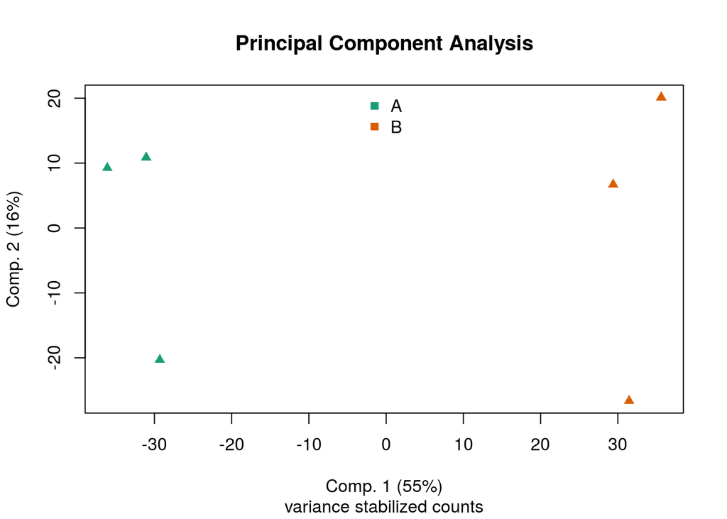

```r
dat <- spruce.vst[,substr(colnames(spruce.vst),1,1) != "D"]
pc <- prcomp(t(dat))
percent <- round(summary(pc)$importance[2,]*100)
plot(pc$x[,1],
     pc$x[,2],
     xlab=paste("Comp. 1 (",percent[1],"%)",sep=""),
     ylab=paste("Comp. 2 (",percent[2],"%)",sep=""),
     col=pal[as.integer(factor(substr(colnames(dat),1,1)))],
     pch=17,
     main="Principal Component Analysis",sub="variance stabilized counts")

legend("top",legend = c("A","B"),
       pch=15,
       col=pal[1:2],
       bty="n")
```

#### 3.5.1.2 Significant genes only

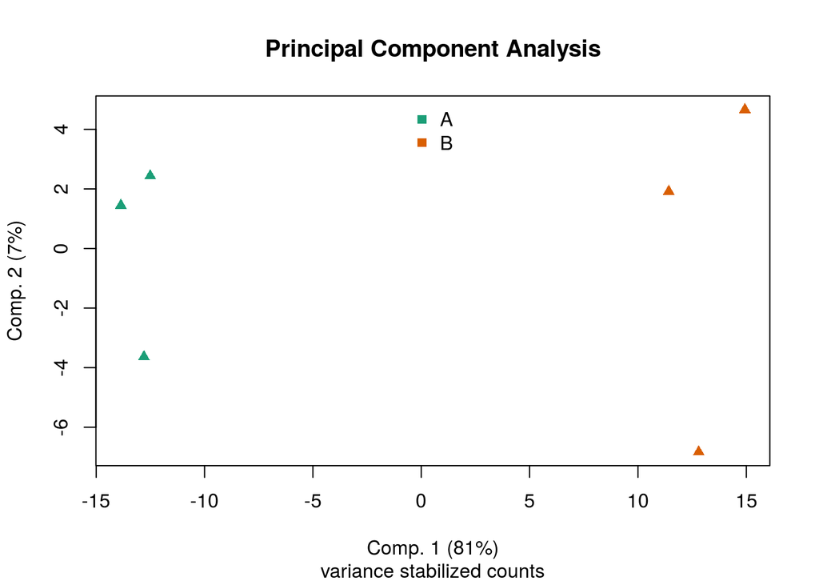

```r
dat <- spruce.vst[s.genes,
                  substr(colnames(spruce.vst),1,1) != "D"]
pc <- prcomp(t(dat))
percent <- round(summary(pc)$importance[2,]*100)
plot(pc$x[,1],
     pc$x[,2],
     xlab=paste("Comp. 1 (",percent[1],"%)",sep=""),
     ylab=paste("Comp. 2 (",percent[2],"%)",sep=""),
     col=pal[as.integer(factor(substr(colnames(dat),1,1)))],
     pch=17,
     main="Principal Component Analysis",sub="variance stabilized counts")

legend("top",legend = c("A","B"),
       pch=15,
       col=pal[1:2],
       bty="n")
```

### 3.5.2 Pine

#### 3.5.2.1 Excluding Dark

Remove the D samples (Dark)

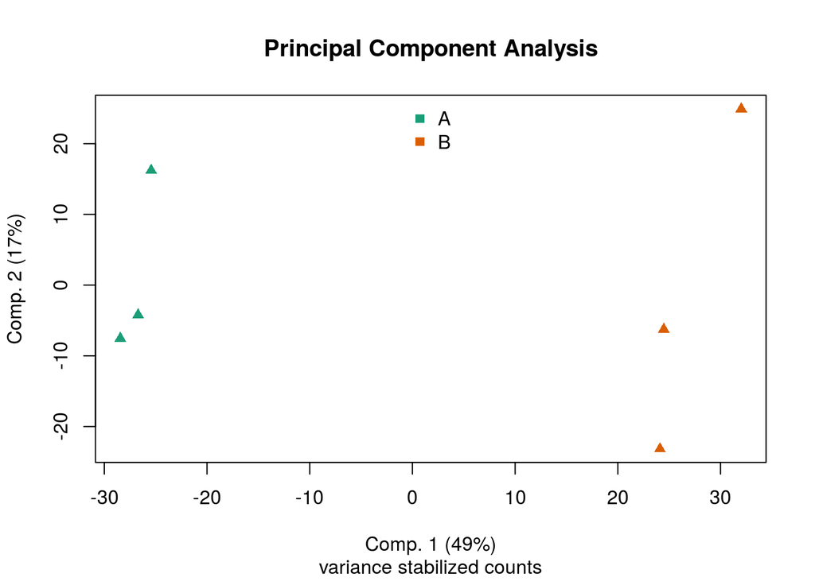

```r
dat <- pine.vst[,substr(colnames(pine.vst),1,1) != "D"]
pc <- prcomp(t(dat))
percent <- round(summary(pc)$importance[2,]*100)
plot(pc$x[,1],
     pc$x[,2],
     xlab=paste("Comp. 1 (",percent[1],"%)",sep=""),
     ylab=paste("Comp. 2 (",percent[2],"%)",sep=""),
     col=pal[as.integer(factor(substr(colnames(dat),1,1)))],
     pch=17,
     main="Principal Component Analysis",sub="variance stabilized counts")

legend("top",legend = c("A","B"),
       pch=15,
       col=pal[1:2],
       bty="n")
```

#### 3.5.2.2 Significant genes only

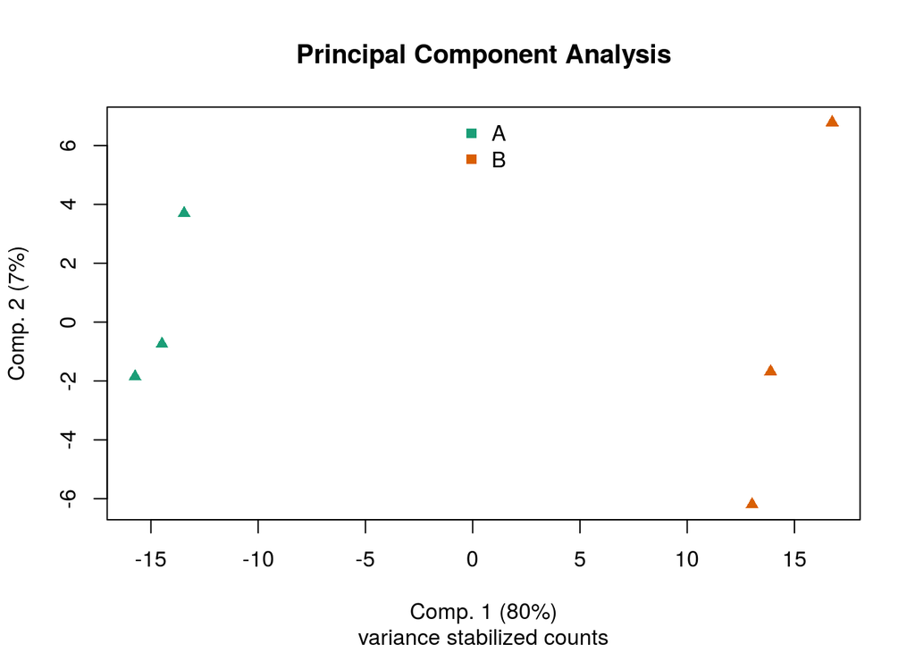

```r
dat <- pine.vst[p.genes,
                  substr(colnames(pine.vst),1,1) != "D"]
pc <- prcomp(t(dat))
percent <- round(summary(pc)$importance[2,]*100)
plot(pc$x[,1],
     pc$x[,2],
     xlab=paste("Comp. 1 (",percent[1],"%)",sep=""),
     ylab=paste("Comp. 2 (",percent[2],"%)",sep=""),
     col=pal[as.integer(factor(substr(colnames(dat),1,1)))],
     pch=17,
     main="Principal Component Analysis",sub="variance stabilized counts")

legend("top",legend = c("A","B"),
       pch=15,
       col=pal[1:2],
       bty="n")
```

## 3.6 Heatmap

### 3.6.1 Feature selection

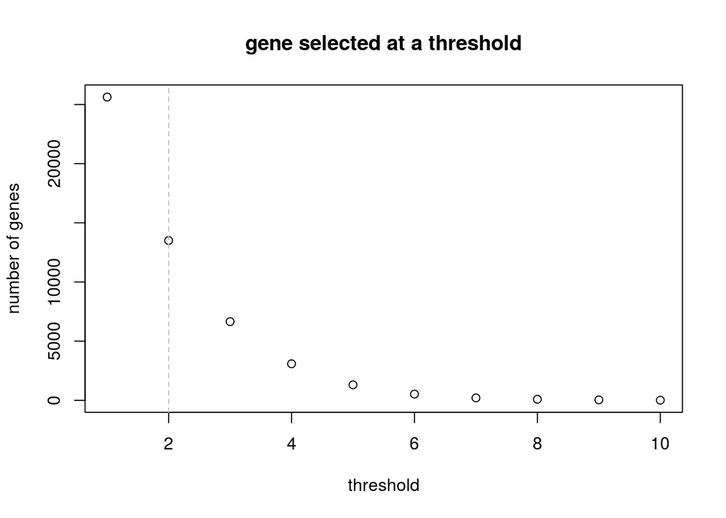

```r
s.sels <- sapply(1:10, function(i){
  featureSelect(spruce.vst,
                factor(sub("\\.\\d+$","",colnames(spruce.vst))),
                i)
})

plot(colSums(s.sels),main="gene selected at a threshold",xlab="threshold",
     ylab="number of genes")
abline(v=2,lty=2,col="grey")
```

Select the genes that have vst >= 2 in at least 2 rep out of 3

```r
s.sel <- s.sels[,2]
```

### 3.6.2 Feature selection - Pine

We select features to reduce the biological noise for visualisation

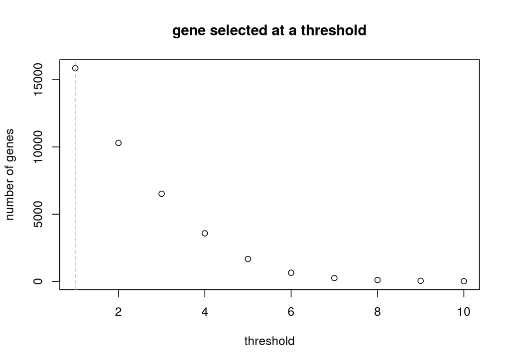

```r
p.sels <- sapply(1:10, function(i){
  featureSelect(pine.vst,
                factor(sub("\\.\\d+$","",colnames(pine.vst))),
                i)
})


plot(colSums(p.sels),main="gene selected at a threshold",xlab="threshold",
     ylab="number of genes")
abline(v=1,lty=2,col="grey")
```

Select the genes that have vst >= 1 in at least 2 rep out of 3

```r
p.sel <- p.sels[,1]
```